# Exponential smoothing examples

anil

2026-10-10

# Understanding `HoltWinters()` in R

Imagine an ice-cream shop records its monthly sales. Sales generally increase over time, and summer sales are higher than winter sales.

The Holt-Winters method estimates three components:

- **Level:** The current baseline sales.
- **Trend:** Whether sales are increasing or decreasing.
- **Seasonality:** The repeating monthly pattern.

## 1. Understanding the parameters

The R function has the following form:

```r
HoltWinters(
  x,
  alpha = NULL,
  beta = NULL,
  gamma = NULL
)
```

The parameters control how quickly the model updates its estimates.

| Parameter | Controls | Simple interpretation |
| --- | --- | --- |
| `alpha` | Level | How quickly the baseline sales estimate responds to recent observations |
| `beta` | Trend | How quickly the estimated trend responds to recent changes |
| `gamma` | Seasonality | How quickly the seasonal pattern is updated |

Each parameter is generally between 0 and 1.

**A larger value gives more weight to recent information; a smaller value makes the corresponding estimate change more slowly.**

For example: - `alpha = 0.9`: The level estimate responds strongly to recent observations. - `alpha = 0.1`: The level estimate changes more gradually. - `beta = 0.9`: The trend estimate responds strongly to recent changes in trend. - `gamma = 0.1`: The seasonal estimates change gradually.

These parameters do not directly specify how much sales will increase. They control how the model learns from the data.

## 2. Create a small dataset

Let us use monthly ice-cream sales for two years.

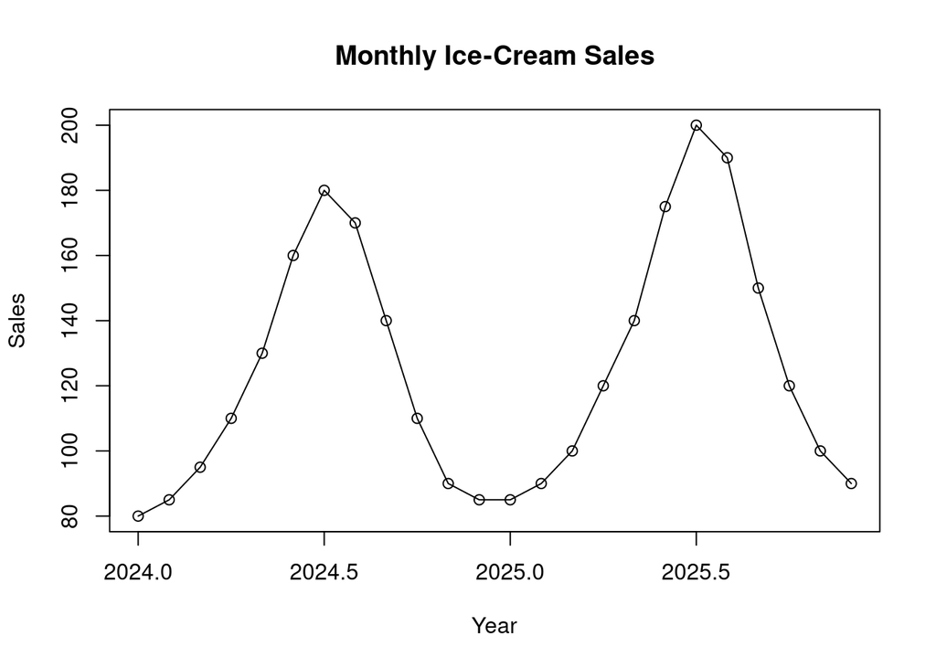

```r
# Monthly ice-cream sales for 2 years
sales_data <- c(
  80, 85, 95, 110, 130, 160, 180, 170, 140, 110, 90, 85,
  85, 90, 100, 120, 140, 175, 200, 190, 150, 120, 100, 90
)

# Convert to a monthly time series
sales <- ts(
  sales_data,
  start = c(2024, 1),
  frequency = 12
)

plot(sales,
     main = "Monthly Ice-Cream Sales",
     xlab = "Year",
     ylab = "Sales",
     type = "o")
```

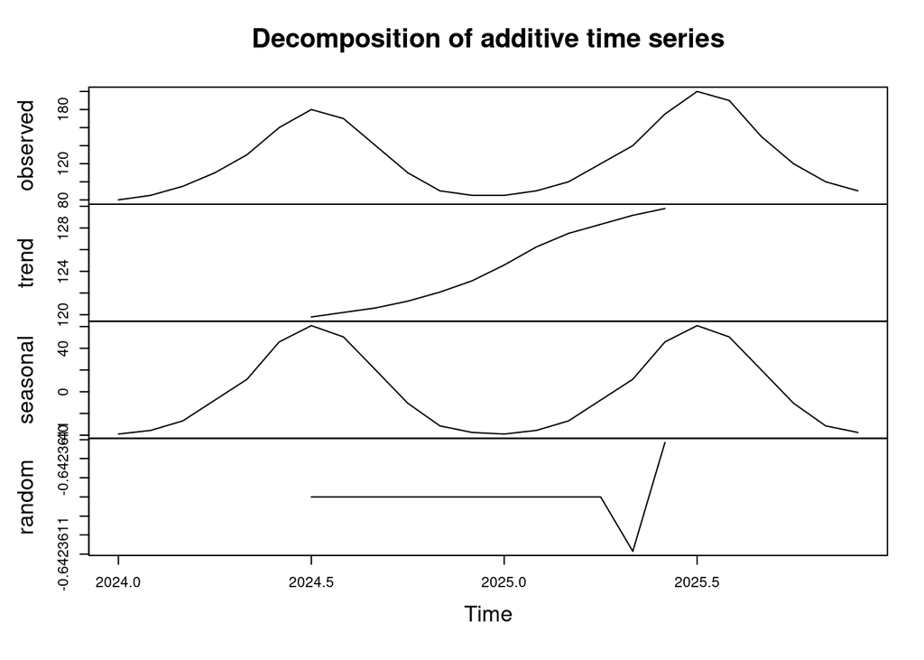

```r
plot(stats::decompose(sales))
```

**What can we observe?**

1. Sales generally increase from the first year to the second.
2. Sales are higher around June, July and August.
3. Sales fall during the colder months.

Therefore, the data contains **level, trend and seasonality**.

Because we have only two years of observations, the example is useful for learning the function, but it is a very small dataset for reliably estimating seasonal patterns.

## 3. What happens when we change `alpha`?

Alpha controls how quickly the model updates its estimate of the level.

### Experiment A: Low alpha

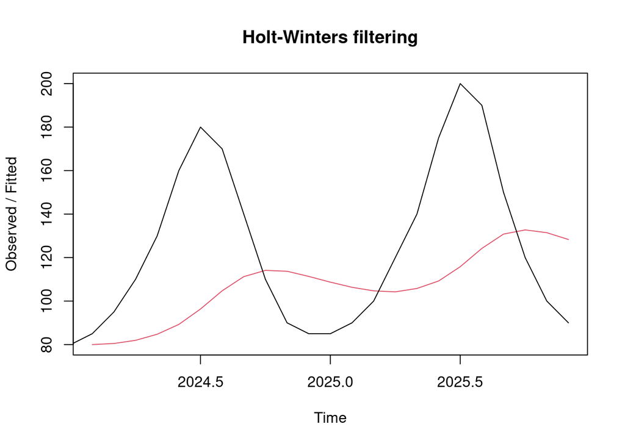

```r
fit_low_alpha <- HoltWinters(
  sales,
  alpha = 0.1,
  beta = FALSE,
  gamma = FALSE
)

plot(fit_low_alpha)
```

Here:

- `alpha = 0.1`: The level responds relatively slowly to new observations.
- `beta = FALSE`: The model does not estimate a separate trend.
- `gamma = FALSE`: The model does not estimate seasonality.

This is effectively **simple exponential smoothing**.

### Experiment B: High alpha

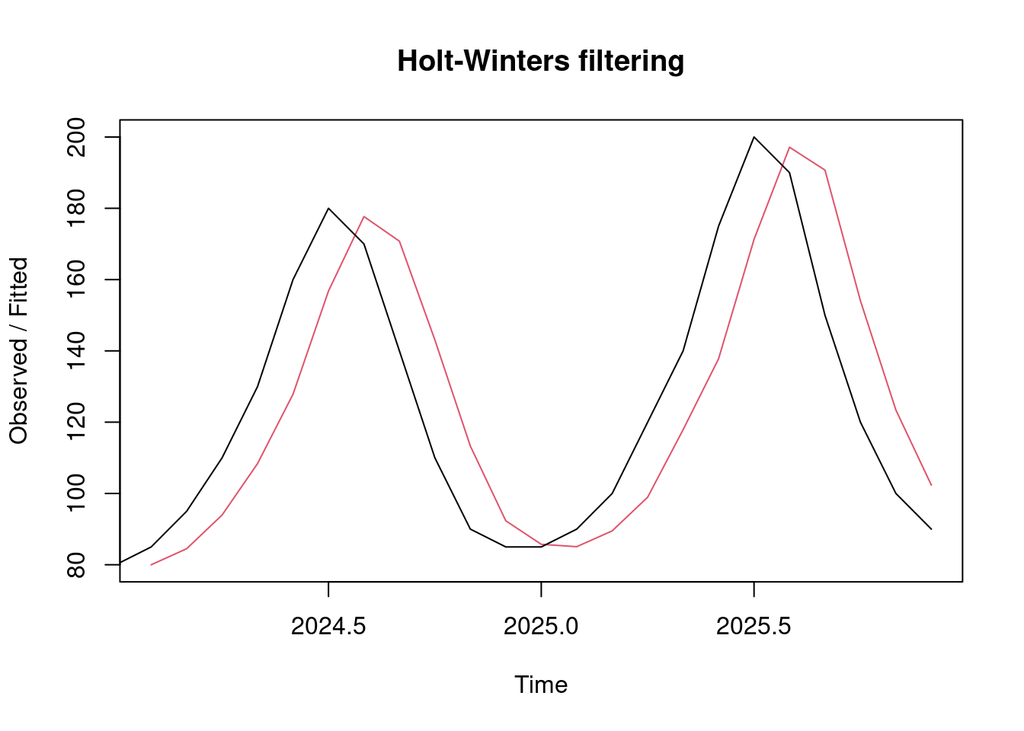

```r
fit_high_alpha <- HoltWinters(
  sales,
  alpha = 0.9,
  beta = FALSE,
  gamma = FALSE
)

plot(fit_high_alpha)
```

Here, the level estimate responds much more strongly to recent observations.

**interpretation:**

Imagine that sales suddenly increase because a nearby college opens.

- With low alpha, the estimated level adjusts gradually.
- With high alpha, the estimated level adjusts more quickly.

However, high alpha does not automatically mean better forecasts. If the data is noisy, reacting strongly to every observation may be undesirable.

**Important:** These two experiments intentionally disable trend and seasonality to isolate the effect of alpha.

## 4. What happens when we change `beta`?

Beta controls how quickly the estimated trend changes.

To demonstrate beta, we should enable the trend component.

### Experiment A: Low beta

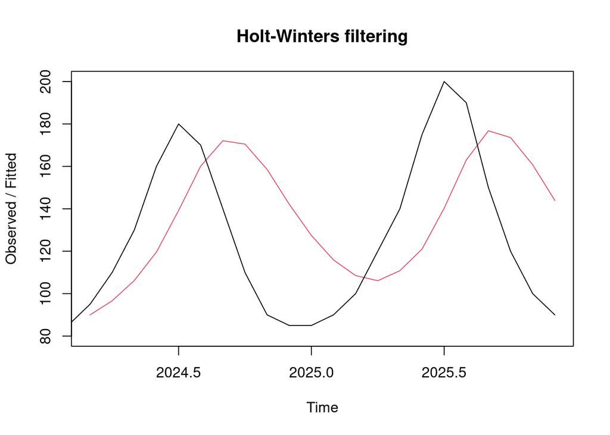

```r
fit_low_beta <- HoltWinters(
  sales,
  alpha = 0.3,
  beta = 0.1,
  gamma = FALSE
)

plot(fit_low_beta)
```

### Experiment B: High beta

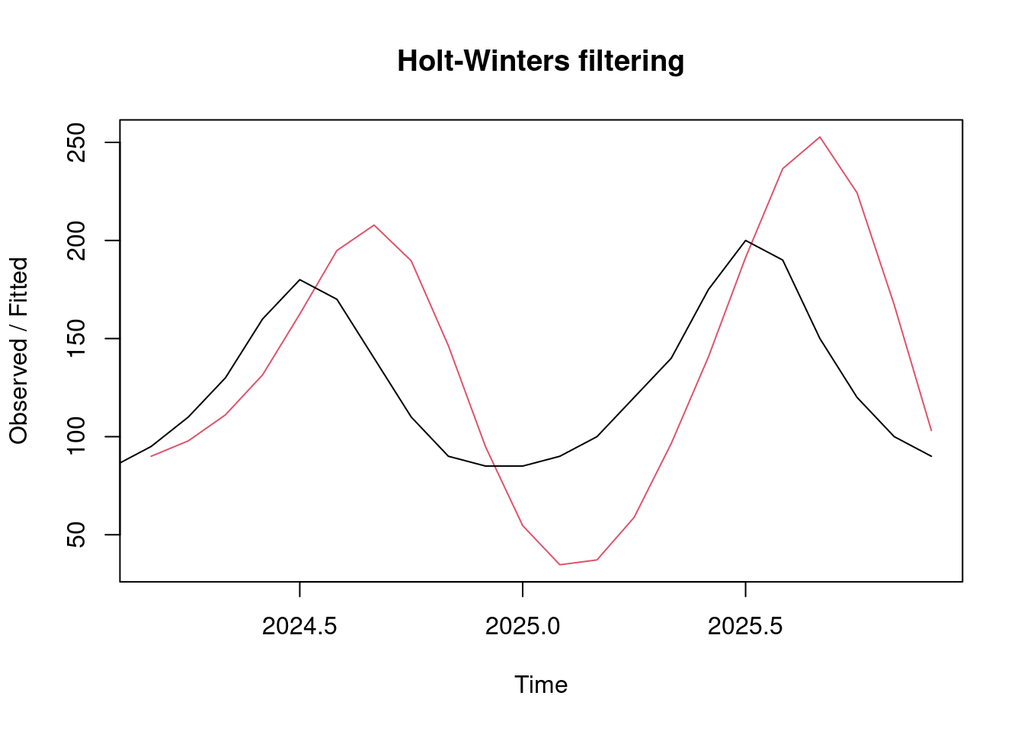

```r
fit_high_beta <- HoltWinters(
  sales,
  alpha = 0.3,
  beta = 0.9,
  gamma = FALSE
)

plot(fit_high_beta)
```

Here, `gamma = FALSE` disables seasonality, allowing us to focus on the level and trend.

| Beta value | Interpretation |
| --- | --- |
| `beta = 0.1` | The trend estimate changes relatively slowly. |
| `beta = 0.9` | The trend estimate responds more strongly to recent changes. |

**Industry example:** A food delivery company observes that its orders are growing.

- Low beta makes the estimated growth rate change gradually.
- High beta allows the estimated growth rate to react more quickly when the recent growth pattern changes.

Remember that beta controls the updating of the trend estimate; it does not directly set the size of the trend.

## 5. What happens when we change `gamma`?

Gamma controls how quickly the estimated seasonal pattern changes.

For ice-cream sales, summer is usually busier than winter.

Imagine that summer sales increase more than expected because of a heatwave or a successful advertising campaign.

### Experiment A: Low gamma

```r
fit_low_gamma <- HoltWinters(
  sales,
  alpha = 0.3,
  beta = 0.1,
  gamma = 0.1
)

plot(fit_low_gamma)
```

[output not shown]

### Experiment B: High gamma

```r
fit_high_gamma <- HoltWinters(
  sales,
  alpha = 0.3,
  beta = 0.1,
  gamma = 0.9
)

plot(fit_high_gamma)
```

[output not shown]

| Gamma value | Interpretation |
| --- | --- |
| `gamma = 0.1` | Seasonal estimates change relatively slowly. |
| `gamma = 0.9` | Seasonal estimates respond more strongly to recent seasonal observations. |

**Industry interpretation:**

Suppose ice-cream sales during July have increased substantially compared with previous years.

- Low gamma adjusts the July seasonal estimate gradually.
- High gamma allows the July seasonal estimate to respond more quickly.

A high gamma can also react to unusual observations, so it is not necessarily better.

**Note:** Because this dataset contains only two years of observations, the gamma experiment is illustrative. More years of data would help establish whether the seasonal pattern is genuinely changing.

# 6. What does `FALSE` mean in `HoltWinters()`?

This is particularly important for understanding the function.

In `HoltWinters()`, setting `beta = FALSE` disables the trend component, while setting `gamma = FALSE` disables the seasonal component.

Let’s examine the combinations.

### Case A: `beta = FALSE`, `gamma = FALSE`

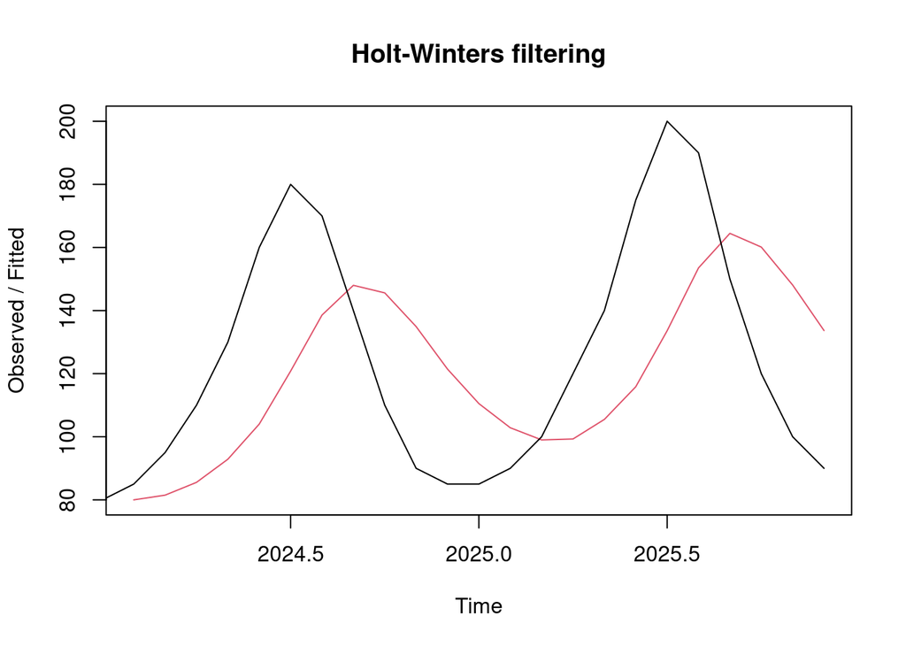

```r
fit_ses <- HoltWinters(
  sales,
  alpha = 0.3,
  beta = FALSE,
  gamma = FALSE
)

plot(fit_ses)
```

The model becomes:

**Level only → Simple Exponential Smoothing**

It does not explicitly estimate a trend or seasonal component.

### Case B: `beta` is numeric, `gamma = FALSE`

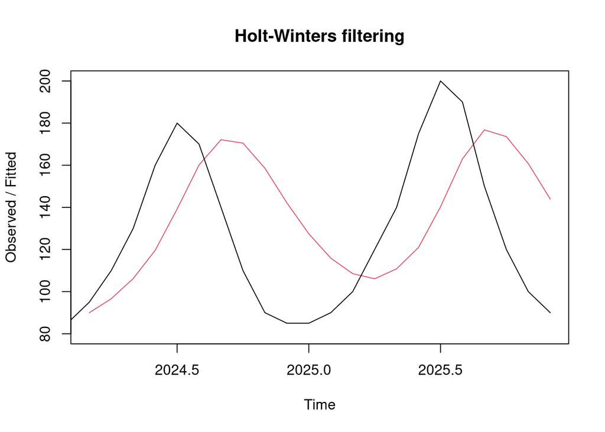

```r
fit_holt <- HoltWinters(
  sales,
  alpha = 0.3,
  beta = 0.1,
  gamma = FALSE
)

plot(fit_holt)
```

The model becomes:

**Level + Trend → Holt’s linear method**

It estimates the level and trend, but does not estimate seasonality.

### Case C: `beta` and `gamma` are numeric

```r
fit_hw <- HoltWinters(
  sales,
  alpha = 0.3,
  beta = 0.1,
  gamma = 0.1
)

plot(fit_hw)
```

[output not shown]

The model becomes:

**Level + Trend + Seasonality → Holt-Winters**

### Summary

| Code setting | Model | Components |
| --- | --- | --- |
| `beta = FALSE, gamma = FALSE` | Simple exponential smoothing | Level |
| `beta = 0.1, gamma = FALSE` | Holt’s linear method | Level + Trend |
| `beta = 0.1, gamma = 0.1` | Holt-Winters | Level + Trend + Seasonality |

When you supply numeric values for alpha, beta and gamma, you are **fixing those smoothing parameters** rather than asking R to estimate them automatically.

### What about `alpha = FALSE`?

**do not use `alpha = FALSE`**. Alpha is a smoothing parameter, not a switch for disabling a component. Use a numeric value such as `alpha = 0.2` or `alpha = 0.8`.

## 7. What happens if we do not specify alpha, beta and gamma?

So far, we have selected the values ourselves. But in practice, we often let R estimate the smoothing parameters.

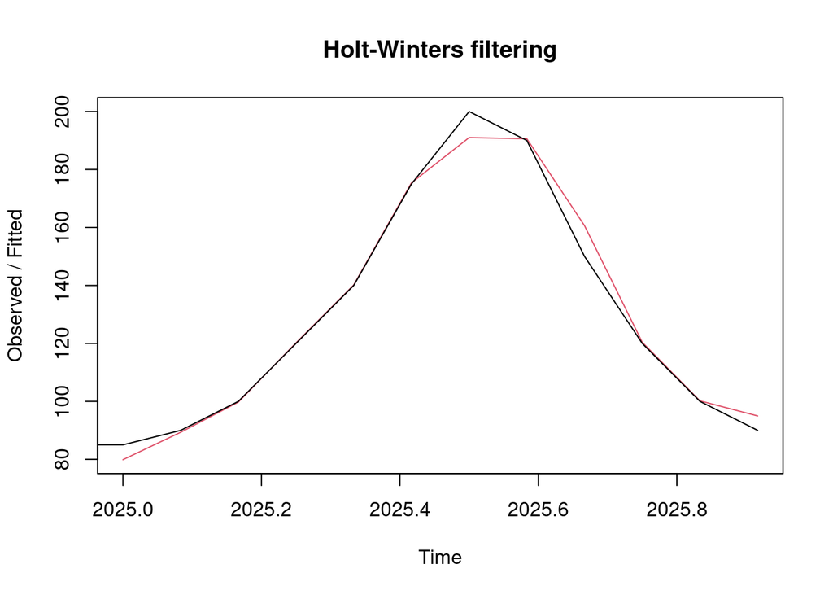

```r
fit_auto <- HoltWinters(sales)

plot(fit_auto)
```

```r
fit_auto$alpha
```

```
## alpha
##     1
```

```r
fit_auto$beta
```

```
## beta
##    0
```

```r
fit_auto$gamma
```

```
## gamma
##   0.1
```

When the parameters are omitted, `HoltWinters()` attempts to select them by minimizing the in-sample squared one-step-ahead forecast errors, subject to the model’s constraints.

For this example, R will fit a seasonal Holt-Winters model by default.

You can inspect the fitted values and the estimated parameters using:

```r
fit_auto
```

```
## Holt-Winters exponential smoothing with trend and additive seasonal component.
##
## Call:
## HoltWinters(x = sales)
##
## Smoothing parameters:
##  alpha: 1
##  beta : 0
##  gamma: 0.1
##
## Coefficients:
##           [,1]
## a   127.482639
## b     1.013258
## s1  -38.940972
## s2  -35.607639
## s3  -26.857639
## s4   -7.690972
## s5   11.475694
## s6   45.850694
## s7   60.850694
## s8   50.434028
## s9   20.017361
## s10 -10.607639
## s11 -31.440972
## s12 -37.482639
```

| Parameter | Low value | High value |
| --- | --- | --- |
| Alpha | Level adjusts slowly | Level adjusts quickly |
| Beta | Trend adjusts slowly | Trend adjusts quickly |
| Gamma | Seasonality adjusts slowly | Seasonality adjusts quickly |

The three models can be remembered as:

- **Simple Exponential Smoothing:** Level only.
- **Holt’s method:** Level + Trend.
- **Holt-Winters:** Level + Trend + Seasonality.

And the role of `FALSE` is:

> **`beta = FALSE` switches off the trend component; `gamma = FALSE` switches off the seasonal component.**

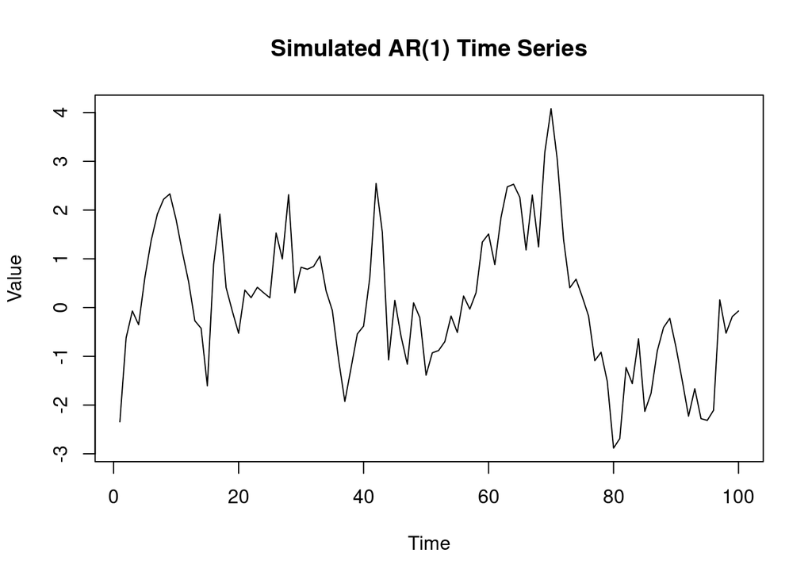

```r
set.seed(123)

# Generate 100 observations from an AR(1) process
x <- arima.sim(
  model = list(ar = 0.8),
  n = 100
)

# Plot the simulated time series
plot(x,
     type = "l",
     main = "Simulated AR(1) Time Series",
     xlab = "Time",
     ylab = "Value")
```

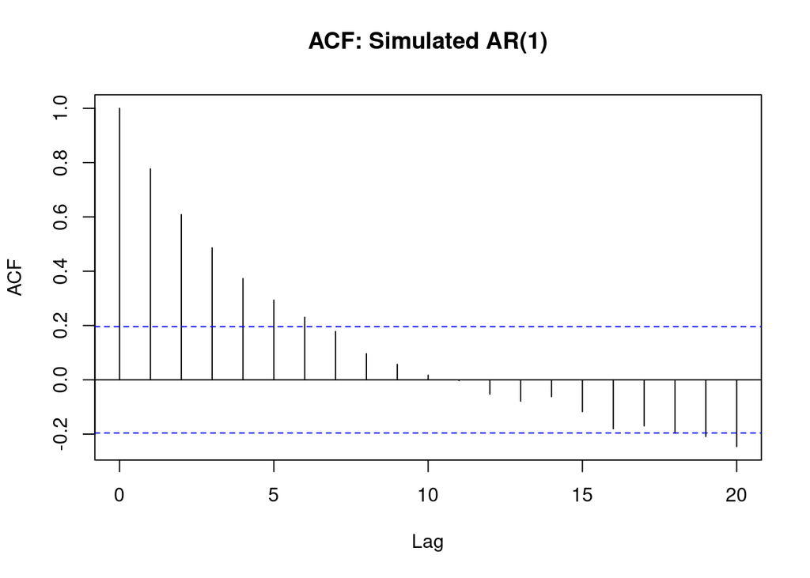

```r
# ACF
acf(x, main = "ACF: Simulated AR(1)")
```

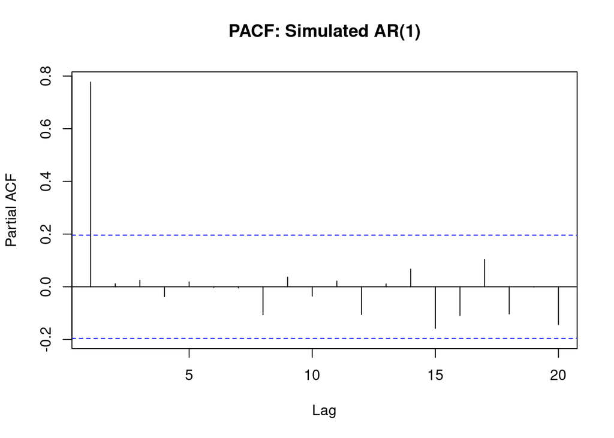

```r
# PACF
pacf(x, main = "PACF: Simulated AR(1)")
```

Here is the R program for simulating a Moving Average (MA(1)) time series, similar to your AR(1) program.

## R Program: Simulated MA(1) Time Series

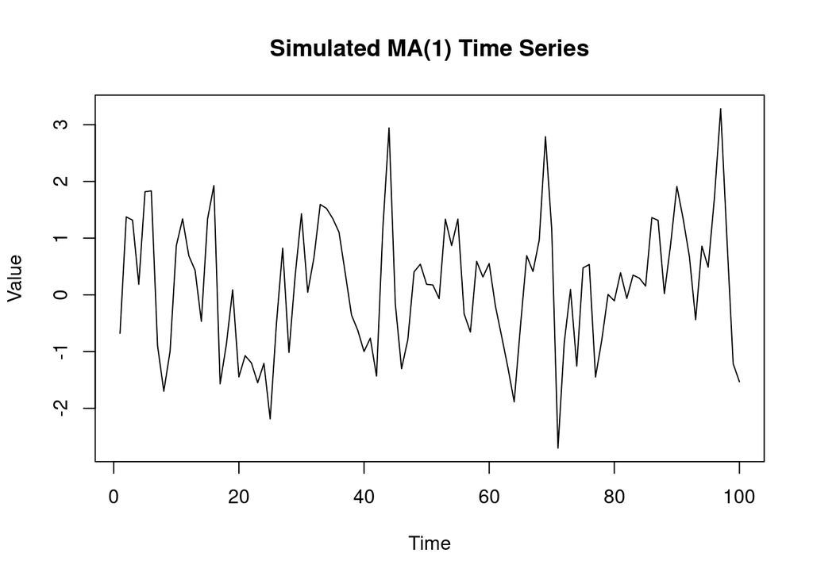

```r
set.seed(123)

# Generate 100 observations from an MA(1) process
x <- arima.sim(
  model = list(ma = 0.8),
  n = 100
)

# Plot the simulated time series
plot(x,
     type = "l",
     main = "Simulated MA(1) Time Series",
     xlab = "Time",
     ylab = "Value")
```

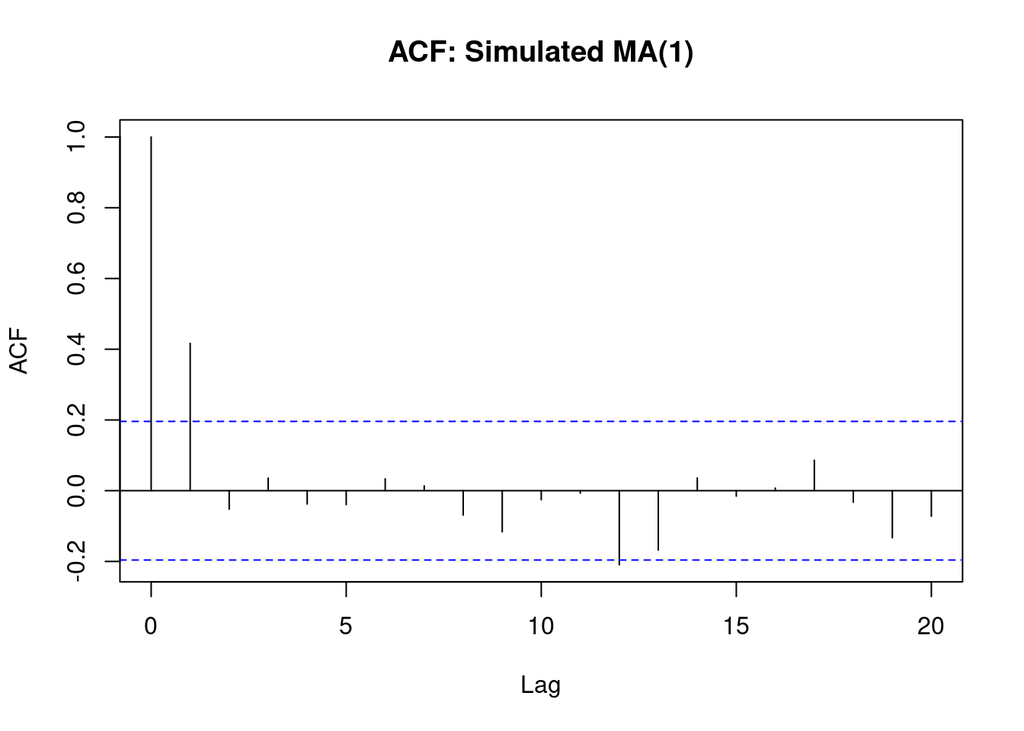

```r
# ACF
acf(x, main = "ACF: Simulated MA(1)")
```

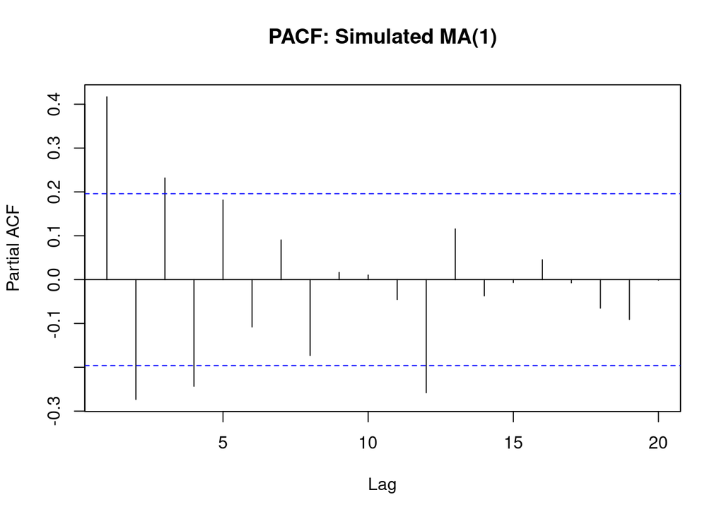

```r
# PACF
pacf(x, main = "PACF: Simulated MA(1)")
```

## Explanation

1. `set.seed(123)` — ensures that the same random observations are generated each time.
2. `model = list(ma = 0.8)` — specifies an MA(1) model with moving average coefficient $= 0.8$.
3. `n = 100` — generates 100 observations.
4. `plot(x)` — displays the simulated time series.
5. `acf(x)` — displays the Autocorrelation Function.
6. `pacf(x)` — displays the Partial Autocorrelation Function.

## Expected ACF and PACF behavior

[output not shown]

### Mathematical model

The MA(1) model is

$$X_t = \varepsilon_t +
\theta\varepsilon_{t-1}$$

where:

- $X_t$ is the current observation.
- $\varepsilon_t$ is the current random error.
- $\varepsilon_{t-1}$ is the previous random error.
- $\theta$ is the moving average coefficient, set to (0.8) in this example.

For an MA(1) process, the theoretical ACF is zero for lags greater than 1. However, the sample ACF may show small nonzero values at higher lags because the data contain only 100 observations.

To simulate an MA(2) (Moving Average of order 2) time series in R, specify two moving average coefficients using `ma = c(0.8, 0.5)`.

## R Program: Simulated MA(2) Time Series

```
set.seed(123)

# Generate 100 observations from an MA(2) process
x <- arima.sim(
  model = list(ma = c(0.8, 0.5)),
  n = 100
)

# Plot the simulated time series
plot(x,
     type = "l",
     main = "Simulated MA(2) Time Series",
     xlab = "Time",
     ylab = "Value")

# ACF
acf(x, main = "ACF: Simulated MA(2)")

# PACF
pacf(x, main = "PACF: Simulated MA(2)")
```

## Explanation

The MA(2) model is represented as

$$X_t = \varepsilon_t +
\theta_1\varepsilon_{t-1} + \theta_2\varepsilon_{t-2}$$

For this example,

$$X_t = \varepsilon_t +
0.8\varepsilon_{t-1} + 0.5\varepsilon_{t-2}$$

- `ma = c(0.8, 0.5)` specifies two moving average coefficients.
- The current observation depends on the current random error and the previous two random errors.
- `n = 100` generates 100 observations.

## Expected ACF and PACF patterns

| Function | Expected behavior for MA(2) |
| --- | --- |
| ACF | Cuts off after lag 2 |
| PACF | Generally tails off gradually |

The ACF helps identify the order of a moving average model. For an MA(2) process, significant autocorrelations are theoretically expected at lags 1 and 2, while autocorrelations beyond lag 2 are zero. In a finite sample, some higher-lag values may still appear outside the confidence limits due to random variation.

reference book https://otexts.com/fpp2/